# Tema II.2: Teoría de la Probabilidad

Autor/a

LÿRA  
L.RodriguezAragon@uclm.es

Fecha de publicación

22 de febrero de 2026

**Estadística (Grados en Ingeniería 2025 / 2026)**

Licesio J. Rodríguez Aragón  
Escuela Ing. Industrial y Aeroespacial de Toledo  
Departamento de Matemáticas  
Universidad de Castilla-La Mancha

## Bloque II: Cálculo de Probabilidades

# Tema II.2: Teoría de la Probabilidad [(p. 344)](https://elibro.net/es/ereader/bibliotecauclm/60046?page=386)

### Reglas generales de la probabilidad

- $0\leq P(A) \leq 1$ para cualquier suceso $A$.
- $P(S)=1$.
- Para cualquier suceso $A$,
  $$P(\text{no ocurra } A)=1-P(A).$$
- **Relga de la suma:** Si $A$ y $B$ son sucesos **disjuntos**, entonces,
  $$P(A\text{ o }B)=P(A)+P(B)$$

### Regla de la multiplicación para sucesos independientes

Dos sucesos A y B son **independientes** si el conocimiento de que ha ocurrido uno de ellos no cambia la probabilidad de que ocurra el otro. Si A y B son independientes,

$$P(A\text{ y }B) = P(A)P(B).$$

Ejemplo:

- Los sucesivos lanzamientos de una moneda son independientes. Para una moneda bien equilibrada la probabilidad de cualquiera de los dos resultados sigue siendo la misma después de haber realizado una o varias tiradas.
- Los colores de las sucesivas cartas de una baraja no son independientes. La probabilidad de obtener una carta roja es de $0.5=26/52$. Una vez que hemos comprobado que la primera carta es roja, sabemos que sólo quedan $25$ rojas en el mazo y la probabilidad de que la segunda sea roja es de $0.49=25/51$.

**Ejercicio (5.22 [p.348](https://elibro.net/es/ereader/bibliotecauclm/60046?page=390) ):** Notas de secundaria. Selecciona al azar a un estudiante universitario de primer curso y pregúntale qué calificación obtuvo en la prueba de acceso a la universidad. He aquí las probabilidades de obtener una determinada calificación en base a una gran encuesta a estudiantes de primer curso:

| Resultado | 5-5.9 | 6-6.9 | 7-7.9 | 8-8.9 | 9-10 |
| --- | --- | --- | --- | --- | --- |
| Probabilidad | 0.41 | 0.23 | 0.29 | 0.06 | 0.01 |

- Escoge al azar a dos estudiantes de primer curso. ¿Por qué podemos suponer que su calificación en la prueba de acceso a la universidad es independiente?
- ¿Cuál es la probabilidad de que los dos estudiantes obtuvieran una calificación mayor o igual que 9?
- ¿Cuál es la probabilidad de que el primero de los estudiantes obtuviera una calificación mayor o igual que 9 y el segundo menor que 6?

**Ejemplo 5.3 [p. 349](https://elibro.net/es/ereader/bibliotecauclm/60046?page=391) :** Un cable submarino transatlántico está provisto de repetidores que amplifican la señal. Si falla un repetidor, éste debe ser reparado. Para ello hay que recuperar el cable y llevarlo hasta la superficie a un coste elevado. Cada repetidor tiene una probabilidad de 0.999 de funcionar correctamente durante 10 años. Supón que los repetidores fallan de forma independiente los unos de los otros. (Esta suposición significa que no hay “causas comunes”, como por ejemplo un terremoto, que pudieran afectar a varios repetidores simultáneamente.) Sea A el suceso que indica que el repetidor si funciona correctamente durante 10 años.

- La probabilidad de que dos repetidores funcionen correctamente durante 10 años es,
  $$P(A_1 \text{ y } A_2)$$
- Para un cable con 10 repetidores la probabilidad de que no fallen durante 10 años es,
  $$P(A_1 \text{ y } A_2 \dots \text{ y } A_{10})$$
- La probabilidad de que un cable con 300 repetidores funcione correctamente durante 10 años es…

**Ejercicio (5.4 [p.351](https://elibro.net/es/ereader/bibliotecauclm/60046?page=393)):** Luces de adorno. Unas luces de adorno de Navidad están formadas por un grupo de 20 bombillas. Éstas se conectan en serie, de manera que si falla una bombilla se apaga toda la serie. Durante un periodo de 3 años, cada bombilla tiene una probabilidad de 0.02 de fallar. El fallo de bombillas se produce de forma independiente. ¿Cuál es la probabilidad de que en un periodo de 3 años un adorno de 20 bombillas no se apague?

**Ejercicio (5.5 [p.351](https://elibro.net/es/ereader/bibliotecauclm/60046?page=393)):** Detección de esteroides. A un atleta sospechoso de haber tomado esteroides se le hacen dos pruebas independientes de detección de esteroides. La prueba A tiene una probabilidad de 0.9 de dar positivo si se han utilizado esteroides. La prueba B tiene una probabilidad de 0.8 de dar positivo si se han utilizado esteroides. ¿Cuál es la probabilidad de que ninguna de las dos pruebas dé positivo si se han utilizado esteroides?

**Ejercicio (5.11 [p.356](https://elibro.net/es/ereader/bibliotecauclm/60046?page=398)):** Un fabricante de automóviles compra circuitos integrados de un determinado proveedor. Este proveedor envía un gran lote que contiene un $5\%$ de circuitos integrados defectuosos. Cada circuito integrado escogido de este lote tiene una probabilidad de 0.05 de ser defectuoso. En cada automóvil se instalan 12 circuitos integrados escogidos de forma independiente. ¿Cuál es la probabilidad de que los 12 circuitos integrados de un automóvil funcionen correctamente?

> Autoevaluación II.2.1: Repasa el concepto de independencia de sucesos. Lee los Ejemplos [5.2](https://elibro.net/es/ereader/bibliotecauclm/60046?page=389) y [5.4](https://elibro.net/es/ereader/bibliotecauclm/60046?page=392) e intenta hacer por tu cuenta los Ejercicios [5.3](https://elibro.net/es/ereader/bibliotecauclm/60046?page=391) y [5.6](https://elibro.net/es/ereader/bibliotecauclm/60046?page=393).

### Regla general de la suma para dos sucesos cualesquiera

Para dos sucesos cualesquiera A y B,

$$P (A\text{ o } B) = P (A) + P(B) - P( A \text{ y }B)$$

Si A y B son disjuntos, el suceso $(A \text{ y } B)$ de que ocurran los dos sucesos no contiene ningún resultado y, por tanto, tiene una probabilidad de 0.

**Ejercicio (5.13 [p.357](https://elibro.net/es/ereader/bibliotecauclm/60046?page=399)):** Solicitudes de doctorado. Akima ha presentado solicitudes para hacer el doctorado en la Universidad de Castilla-la Mancha (UCLM) y en el Instituto de Tecnología de Massachusetts (MIT). Akima cree que la probabilidad de que sea admitida en la UCLM es de 0.5, de que lo sea en el MIT es de 0.4 y de que sea admitida en ambas universidades es de 0.2.

- Dibuja un diagrama de Venn. Indica las probabilidades de los sucesos anteriores.
- ¿Son el ser admitida en la UCLM y ser admitida en el MIT sucesos independientes?
- ¿Cuál es la probabilidad de que Akirna no sea admitida en ninguna de las dos universidades?
- ¿Cuál es la probabilidad de que Akima sea admitida en el MIT y que no lo sea en la UCLM?

**Ejercicio (5.16 [p.358](https://elibro.net/es/ereader/bibliotecauclm/60046?page=400)):** Tratamiento médico y edad. El tipo de tratamiento médico que recibe un paciente, ¿depende de su edad? Un gran estudio sobre mujeres a las que se detectó un bulto en el pecho investigó si en el momen to de detección del bulto, el diagnóstico que se hacía era una mamografía seguida de una biopsia o sólo una mamografía. He aquí las probabilidades estimadas en este estudio.

| Biopsia realizada | Sí | No |
| --- | --- | --- |
| Edad menor de 65 | 0.321 | 0.124 |
| Edad igual o superior a 65 | 0.365 | 0.190 |

La suma de las cuatro probabilidades de la tabla da 1, ya que la tabla contiene todos los sucesos posibles.

- ¿Cuál es la probabilidad de que una paciente de este estudio tenga menos de 65 años?¿Y de que tenga 65 o más años?
- ¿Cuál es la probabilidad de que a la paciente se le haga la biopsia? ¿Y de que no se le haga?
- Los sucesos A: “la paciente tiene 65 años o más” y B: “se hace la biopsia”, ¿son independientes? Si la realización de la biopsia fuera independiente de la edad, ¿en el caso de pacientes mayores, la biopsia se hace con menos frecuencia de la esperada?

> Autoevaluación II.2.2: Lee el Ejemplo [5.5](https://elibro.net/es/ereader/bibliotecauclm/60046?page=395) e intenta hacer por tu cuenta el Ejercicio [5.8](https://elibro.net/es/ereader/bibliotecauclm/60046?page=397) . Lee detenidamente el [Resumen 5.2](https://elibro.net/es/ereader/bibliotecauclm/60046?page=397). Los Ejercicios de la [Sección 5.2](https://elibro.net/es/ereader/bibliotecauclm/60046?page=398) están ahora a tu alcance, intenta hacerlos, ante cualquier duda: PREGUNTA.

### Distribución binomial

Una jugadora de baloncesto lanza 5 tiros libres. ¿Cuántas canastas obtiene? Un nuevo tratamiento contra el cáncer de páncreas se ha ensayado en 25 pacientes. En cinco años, ¿cuántos pacientes sobrevivirán? Plantas 10 cerezos, ¿cuántos resistirán el frío del invierno? En todas estas situaciones queremos un modelo de probabilidad para el recuento de éxitos.

### Situación binomial

La distribución de un recuento depende de como se hayan obtenido los datos. He aquí una situación frecuente:

1. Tenemos un determinado número $n$ de observaciones.
2. Las $n$ observaciones son todas independientes. Es decir, saber el resultado de una observación no te indica nada sobre las restantes observaciones.
3. Cada observación tiene dos resultados posibles, que por conveniencia llamaremos “éxito” y “fracaso”.
4. La probabilidad de éxito, llámala $p$, es igual en todas las observaciones.

Lanzar una moneda al aire $n$ veces es un ejemplo de situación binomial.

### Distribución binomial

La distribución del recuento $X$ de éxitos en una situación binomial es la distribución binomial con parámetros $n$ y $p$. El parámetro $n$ es el número de observaciones y $p$ es la probabilidad de éxito de cualquier observación. Los valores de $X$ son números enteros positivos que van de $0$ a $n$.

**Ejemplo 5.8 [p.361](https://elibro.net/es/ereader/bibliotecauclm/60046?page=403):** Obtención de una muestra aleatoria simple. Una ingeniera selecciona una muestra aleatoria simple de $10$ interruptores de un envío de $10.000$. Supón que el $10\%$ de los interruptores del envío es defectuoso (la ingeniera no lo sabe). La ingeniera hace un recuento del número $X$ de interruptores defectuosos en la muestra de $10$. No estamos exactamente ante una situación binomial.

Cuando seleccionas un interruptor, cambia la proporción de interruptores defectuosos que permanecen en el envío. Por tanto, las condiciones de extracción del segundo interruptor no son independientes de las condiciones de extracción del primer interruptor. De todas formas, la extracción de un interruptor entre $10.000$ cambia muy poco la situación de los restantes $9.999$.

En la práctica, la distribución de $X$ es casi una distribución binomial con $n = 10$ y $p = 0.1$.

### Coeficiente binomial

Podemos hallar una fórmula para calcular la probabilidad de que una variable aleatoria binomial tome un valor determinado, sumando las probabilidades de las diferentes maneras de obtener exactamente ese número de éxitos en n observaciones. He aquí un ejemplo que utilizaremos para ilustrar esta idea.

### Coeficiente binomial

El **coeficiente binomial** $\binom{n}{k}$ es el número de subconjuntos distintos de $k$ elementos escogidos de un conjunto con $n$ elementos.

El número de maneras de combinar $k$ éxitos entre $n$ observaciones viene dado por el **coeficiente binomial**

$$\binom{n}{k}=\frac{n!}{k!(n-k)!}$$

para k = 0, 1,2, …, n.

El coeficiente binomial $\binom{n}{k}$ determina el número de maneras con las que $k$ éxitos se pueden distribuir entre $n$ observaciones. La probabilidad binomial $P(X = k)$ es este número multiplicado por la probabilidad de cualquier combinación concreta de los $k$ éxitos entre las $n$ observaciones.

### Probabilidad binomial

Si $X$ tiene una distribución binomial con $n$ observaciones y con una probabilidad $p$ de éxito en cada observación, los posibles valores de $X$ son $0, 1, 2, ..., n$. Si $k$ es uno de estos valores,

$$P(X=k)=\binom{n}{k}p^k(1-p)^{n-k}$$

Esta función se conoce como **función de probabilidad**, ya que asigna a cada punto del espacio muestral $S=\{0,1,\dots,n\}$ su probabilidad.

Es fácil comprobar que:

$$\sum_{k=0}^{n} P(X=k)=\sum_{k=0}^{n} \binom{n}{k}p^k(1-p)^{n-k} = (p+(1-p))^n = 1$$
Usando la fórmula del Binomio de Newton.

**Ejemplo 5.10 [p.364](https://elibro.net/es/ereader/bibliotecauclm/60046?page=403):** El número $X$ de interruptores que no pasan la inspección en el ejemplo 5.8 tiene, aproximadamente, una distribución binomial con $n = 10$ y $p = 0.1$.

La probabilidad de que como máximo un interruptor sea defectuoso es
$$P(X\leq 1)=P(X=1 )+ P(X=0)$$

**Ejercicio (5.23 [p.365](https://elibro.net/es/ereader/bibliotecauclm/60046?page=407)):** Los atletas, ¿terminan la carrera? Una universidad asegura que el $80\%$ de los jugadores de baloncesto del equipo universitario se licencian. Una investigación examina el destino de los $20$ jugadores que se matricularon en la universidad durante un periodo determinado que finalizó hace seis años. De estos jugadores, $11$ se licenciaron y los $9$ restantes abandonaron la universidad antes de licenciarse. Si la afirmación de la universidad es cierta, el número de jugadores de baloncesto que, entre los $20$, se licencian debería tener una distribución binomial con $n = 20$ y $p = 0.8$. ¿Cuál es la probabilidad de que exactamente $11$ de los $20$ jugadores se licencien?

### Media y desviación típica de una distribución binomial

Si un recuento $X$ tiene una distribución binomial con un número de observaciones $n$ y una probabilidad de éxito $p$, la media y la desviación típica de $X$ son

$$\mu=np$$
$$\sigma=\sqrt{np(1-p)}$$

Estas fórmulas sólo se pueden utilizar para distribuciones binomiales.

**Ejemplo 5.11 [p.366](https://elibro.net/es/ereader/bibliotecauclm/60046?page=408):** El recuento X de interruptores defectuosos tiene una distribución binomial con $n = 10$ y $p = 0.1$.

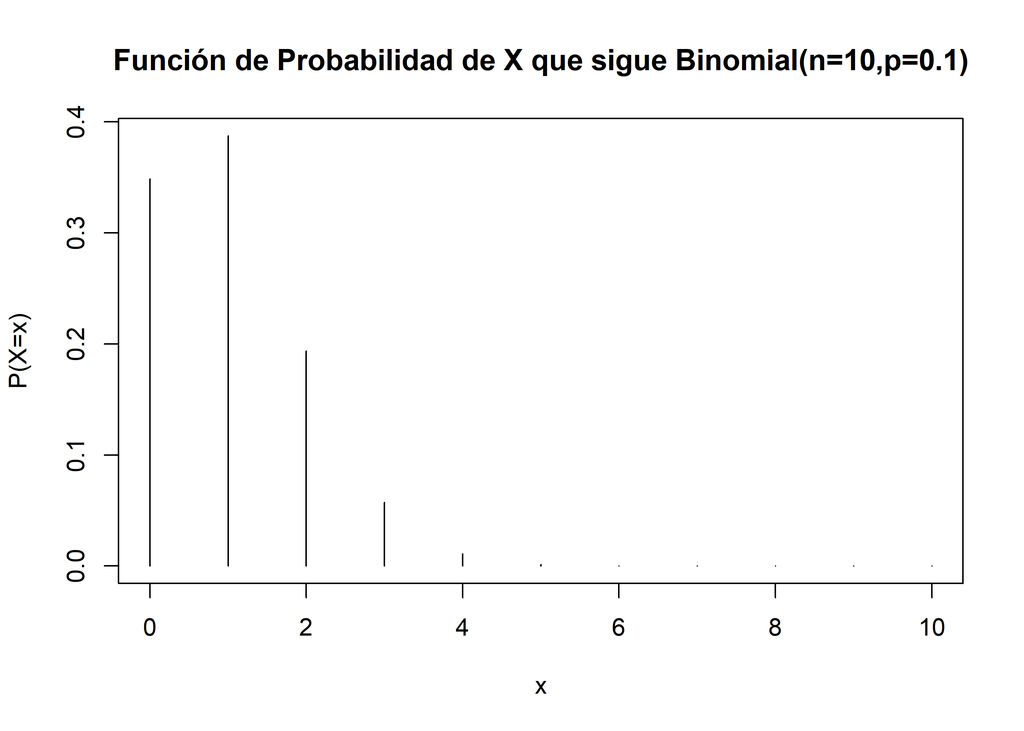

El diagrama de barras muestra esta distribución de probabilidad. La distribución es muy asimétrica. Aunque $X$ puede tomar cualquier valor entero entre $0$ y $10$, las probabilidades de los valores mayores que $5$ son tan pequeñas que no aparecen en el diagrama.

**Ejercicio (5.26 [p.368](https://elibro.net/es/ereader/bibliotecauclm/60046?page=410)):** Los atletas, ¿terminan la carrera?

- Halla el número medio de licenciados entre los $20$ jugadores del ejemplo planteado en el ejercicio 5.23, si la afirmación de la universidad es cierta.
- Halla la desviación típica $\sigma$ del recuento $X$.
- Supón que los $20$ jugadores proceden de una población en la que la probabilidad de licenciarse es $p = 0.9$. ¿Cuál es la desviación típica $\sigma$ del recuento de licenciados? Si $p = 0.99$, ¿cuál es el valor de $\sigma$? ¿Qué indican tus resultados sobre el comportamiento de la desviación típica de una distribución binomial a medida que la probabilidad $p$ de éxito se acerca a $1$?

Nota:

$$\frac{\partial}{\partial p} \sqrt{n\cdot p\cdot (1-p)}= \frac{n(1-2p)}{2\sqrt{n\cdot p \cdot (1-p)}}=0$$
El máximo de $\sigma$ se obtiene con $p=1/2$.

> Autoevaluación II.2.3: Intenta hacer por tu cuenta los Ejercicios [5.21](https://elibro.net/es/ereader/bibliotecauclm/60046?page=407) y [5.24](https://elibro.net/es/ereader/bibliotecauclm/60046?page=409).

### Aproximación normal a distribuciones binomiales

A medida que aumenta el número $n$ de repeticiones, la distribución se parece cada vez más a una normal.

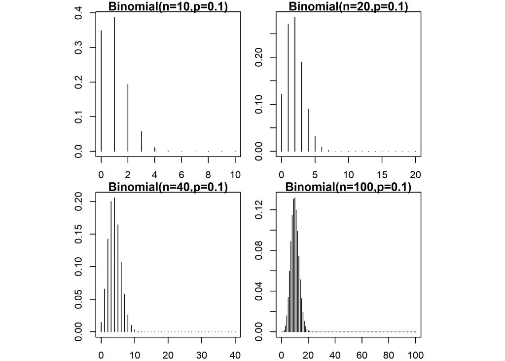

Supón que el recuento $X$ tiene una distribución binomial con $n$ ensayos y una probabilidad de éxito $p$. Cuando $n$ es grande, la distribución de $X$ es aproximadamente normal, $N( np, \sqrt{np(1-p)})$.

Como regla práctica, diremos que podemos utilizar la aproximación normal cuando $n$ y $p$ cumplan que $np\geq 10$ y $n(1-p)\geq 10$.

La aproximación normal es fácil de recordar, ya que dice que $X$ es normal con su media y desviación típica binomiales. La exactitud de la distribución normal mejora a medida que el tamaño $n$ de la muestra aumenta. Dado un valor cualquiera de $n$, la aproximación es más precisa cuando $p$ toma un valor próximo a $1/2$ y menos precisa cuando $p$ toma un valor cercano a $0$ o a $1$. Que utilices o no la aproximación normal depende de lo precisos que deban ser tus cálculos. Para muchos cálculos estadísticos no se necesita una gran precisión. Nuestra regla práctica para la aproximación normal tiene en cuenta esto.

[figure not shown]

El teorema central del límite, entre sus muchos y varaidos resultados, incluye la aproximación de la distribución binomial, o suma de binomiales, por medio de una distribución normal. La [máquina de Galton](https://es.wikipedia.org/wiki/M%C3%A1quina_de_Galton) es un ejemplo real y tangible de esa aproximación.

**Ejercicio (5.22 [p.365](https://elibro.net/es/ereader/bibliotecauclm/60046?page=407))** Una empresa emplea a varios miles de trabajadores, de los cuales el 30% son extranjeros. Si los 15 miembros del comité ejecutivo del sindicato se escogieran al azar entre los trabajadores, el número de extranjeros en el comité tendría una distribución binomial con n = 15 y p = 0.3.

- ¿Cuál es la probabilidad de que exactamente 3 miembros del comité sean extranjeros?
- ¿Cuál es la probabilidad de que como máximo 3 miembros del comité sean extranjeros?

**Ayuda:**

```r
dbinom(3,size=15,prob=0.3)
```

```
[1] 0.1700402
```

```r
dbinom(3,15,0.3)+dbinom(2,15,0.3)+dbinom(1,15,0.3)+dbinom(0,15,0.3)
```

```
[1] 0.2968679
```

```r
pbinom(3,15,0.3)
```

```
[1] 0.2968679
```

**Ejercicio (5.27 [p.371](https://elibro.net/es/ereader/bibliotecauclm/60046?page=413))** Investigación de mercado. Tienes un restaurante en Córdoba. Lees en un estudio de ámbito español llevado a cabo por una asociación de restauración, que el 40% de los adultos de una muestra desea comer pescado cuando come fuera de casa. Para ajustar tu menú al gusto de los cordobeses decides llevar a cabo una encuesta. Obtienes una muestra aleatoria simple de 200 hogares seleccionando al azar números de teléfono de la provincia de Córdoba.

- Si la proporción de gente que desea comer pescado en Córdoba es la misma que la de España en general, es razonable utilizar una distribución binomial con n = 200 y p = 0.4 para describir el recuento X de personas de la muestra que desea comer pescado. Explica por qué.
- Si se cumple que p = 0.4, ¿cuál es el valor de la media del número de gente de tu muestra que desea comer pescado cuando come fuera de casa? ¿Cuál es el valor de la desviación típica?
- ¿Cuál es la probabilidad de que X se halle entre 75 y 85? (Utiliza la aproximación normal.)

**Ayuda:**

```r
pbinom(85,200,0.4)-pbinom(74,200,0.4)
```

```
[1] 0.5726537
```

### Corrección por Continuidad

La aproximación de una distribución binomial, $\mathcal{B}(n,p)$ por una distribución normal, $\mathcal{N}(np,\sqrt{npq})$, cuando $np\geq 10$ y $nq\geq 10$ aproxima una distribución con un espacio muestral finitio por otra con un espacio muestral infinito. En estos casos se aplica una corrección de esta continuidad:
$$P(a\leq X_{\mathcal{B}}\leq b)\approx P(a-\frac{1}{2}\leq X_{\mathcal{N}}\leq b+\frac{1}{2})$$
Igualmente tenemos que:
$$P(X_{\mathcal{B}}= a)\approx P(a-\frac{1}{2}\leq X_{\mathcal{N}}\leq a+\frac{1}{2}).$$
**Ejercicio (5.29 [p.372](https://elibro.net/es/ereader/bibliotecauclm/60046?page=414)):** Errores de muestreo. Una manera de comprobar el efecto de la falta de cobertura, la no-respuesta u otras fuentes de error en una encuesta, consiste en comparar la muestra con características conocidas de la población. Así, por ejemplo, se conoce que un $12\%$ de los estadounidenses adultos son negros. Por tanto, la distribución de la variable $X$ del número de negros en una muestra aleatoria simple de $1.500$ adultos debe ser binomial $(n = 1.500, p = 0.12)$.

- ¿Cuáles son la media y la desviación típica de $X$?
- Utiliza la aproximación normal para hallar la probabilidad de que la muestra contenga como máximo $170$ negros. Asegúrate de comprobar que se cumplen las condiciones necesarias para utilizar la aproximación normal.

**Ayuda:**

```r
pbinom(170,1500,0.12)
```

```
[1] 0.2264761
```

**Ejercicio (5.30 [p.373](https://elibro.net/es/ereader/bibliotecauclm/60046?page=415))** ¿Situación binomial? En cada una de las siguientes situaciones, ¿es razonable suponer que la distribución de la variable X es binomial? Justifica tus respuestas.

- Un fabricante de coches escoge un automóvil cada hora de producción para llevar a cabo una inspección detallada de calidad. Una de las variables registradas es el número de defectos en el acabado de la pintura.
- Se han preseleccionado 100 personas al azar entre los residentes de una gran ciudad para formar parte de un tribunal popular. A cada una de las personas preseleccionadas se le pregunta si está a favor o en contra de la pena de muerte; X es el número de personas que dicen “Sí”.
- Jaime compra cada semana un boleto del sorteo de la ONCE X es el número de veces que gana un premio en un año.

**Ejercicio (5.34 [p.374](https://elibro.net/es/ereader/bibliotecauclm/60046?page=416))** Prueba de percepción extrasensorial. En una prueba de percepción extrasensorial, se le dice a un sujeto que las cartas que no puede ver tienen impresas o una copa, o una espada, o un oro o un basto. Cuando el investigador mira cada una de las 20 cartas de la baraja, el sujeto tiene que decir cuál es el símbolo impreso en la carta. Un sujeto que esté simplemente adivinando tiene una probabilidad de 0.25 de acertar en cada carta.

- El recuento de aciertos en 20 cartas tiene una distribución binomial. ¿Cuáles son los valores de n y p?
- Después de muchas repeticiones, ¿cuál es el número medio de aciertos?
- ¿Cuál es la probabilidad de exactamente 5 aciertos?

**Ayuda:**

```r
dbinom(5,20,0.25)
```

```
[1] 0.2023312
```

**Ejercicio (5.54 [p.388](https://elibro.net/es/ereader/bibliotecauclm/60046?page=430))** Tanques con fugas. En las estaciones de servicio, las fugas en tanques subterráneos de carburante pueden perjudicar el medio ambiente. Se estima que el 25% de estos tanques tienen pérdidas de carburante. Examinas 15 tanques escogidos al azar, y de forma independiente.

- En muestras de 15 depósitos, ¿cuál es la media de tanques que presentan fugas?
- En muestras de 15 depósitos, ¿cuál es la probabilidad de que al menos 10 tanques presenten fugas?
- Supón que ahora tienes una muestra aleatoria de 1.000 tanques escogidos por todo el país, ¿cuál es la probabilidad de que al menos 275 de estos tanques tengan fugas de carburante?

**Ayuda:**

```r
1-pbinom(9,15,0.25)
```

```
[1] 0.000794949
```

```r
1-pbinom(274,1000,0.25)
```

```
[1] 0.03781836
```

> Autoevaluación II.2.4: Intenta hacer por tu cuenta el Ejercicio [5.28](https://elibro.net/es/ereader/bibliotecauclm/60046?page=414) Lee detenidamente el [Resumen 5.3](https://elibro.net/es/ereader/bibliotecauclm/60046?page=414). Los Ejercicios de la [Sección 5.3](https://elibro.net/es/ereader/bibliotecauclm/60046?page=415) están ahora a tu alcance, intenta hacerlos, ante cualquier duda: PREGUNTA.

# Hasta aquí Prueba de Progreso.

### Probabilidad Condicionada

Cuando presentamos las **tablas de contingencia** nos encontramos con la idea de **distribución condicionada**, es decir, la distribución de una variable cuando se cumple una determinada condición. Vamos a introducir esta idea en el contexto de la probabilidad.

**Ejemplo 5.14 [p.377](https://elibro.net/es/ereader/bibliotecauclm/60046?page=419):** He aquí una tabla de contingencia sobre los suicidios acaecidos recientemente, clasificados según el sexo y según si la víctima utilizó o no un arma de fuego para suicidarse.

| SUICIDIOS | Hombre | Mujer | Total |
| --- | --- | --- | --- |
| Arma de Fuego | 16381 | 2559 | 18940 |
| Otra | 9034 | 3536 | 12570 |
| Total | 25415 | 6095 | 31510 |

Escoge un suicidio al azar. ¿Cuál es la probabilidad de que se utilizara un arma de fuego? Debido a que “escoger al azar” da a todos los 31.510 suicidios las mismas posibilidades de ser escogidos, esta probabilidad no es más que la proporción de suicidios en los que se utilizó un arma de fuego:

$$P(\text{arma de fuego})=$$

Escoge un suicidio al azar. ¿Cuál es la probabilidad de que el suicida fuese una mujer?

$$P(\text{mujer})=$$

Nos dicen que el suicidio escogido correspondía a una mujer. Una mirada a la tabla muestra que las posibilidades de que una mujer utilice un arma de fuego son menores que para un hombre.

La probabilidad de que se utilice un arma de fuego, dada la información de que el suicida era una mujer, es

$$P(\text{arma de fuego}|\text{mujer})=$$

Esto es una **probabilidad condicionada**. Puedes leer la barra como “dada la información de que”.

Para hallar la proporción de suicidios que implican a la vez que la víctima sea mujer y que además utilizó un arma de fuego, en primer lugar halla la proporción de mujeres entre los suicidas.

Luego, multiplica por la proporción de mujeres suicidas que utilizaron un arma de fuego.

$$P(\text{mujer y arma de fuego})=P(\text{mujer})\times P(\text{arma de fuego}|\text{mujer})$$

Puedes comprobar que esto es cierto:

$$P(\text{mujer y armas de fuego})=\frac{2559}{31510}=0.081$$

### Regla general de la multiplicación para dos sucesos cualesquiera

La probabilidad de que dos sucesos $A$ y $B$ ocurran simultáneamente se puede hallar de la siguiente manera

$$P(A\text{ y }B) = P(A) P ( B | A)$$

Aquí $P( B | A)$ es la probabilidad de que ocurra $B$ condicionada a que ha ocurrido $\bf{A}$. (ERRATA!!)

**Ejercicio (5.42 [p.380](https://elibro.net/es/ereader/bibliotecauclm/60046?page=422)):** Suicidios.Utiliza la tabla de contingencia del ejemplo 5.14 relativo a tipos de suicidio, para hallar las siguientes probabilidades condicionales:

- P(armas de fuego | hombre)
- P(hombre | armas de fuego)

**Ejercicio (5.41 [p.380](https://elibro.net/es/ereader/bibliotecauclm/60046?page=422))** Comprando en Japón. Una empresa de Zaragoza compra controladores electrónicos a un proveedor japonés .El tesorero de la empresa cree que existe una probabilidad de 0.4 de que en el próximo mes el euro baje con relación al yen japonés. El tesorero también cree que si el euro baja, existe una probabilidad de 0.8 de que el proveedor japonés pida renegociar el contrato. ¿Qué probabilidad ha asignado el tesorero al suceso de que el euro baje y el proveedor pida renegociar el contrato?

**Ejercicio (5.45 [p.384](https://elibro.net/es/ereader/bibliotecauclm/60046?page=426))** Inspección de interruptores. Un envío contiene 10.000 interruptores. De éstos, 1.000 son defectuosos. Un inspector extrae al azar interruptores del envío; por tanto, todos ellos tienen la misma probabilidad de ser escogidos.

- Extrae un interruptor. ¿Cuál es la probabilidad de que sea defectuoso? ¿Cuál es la probabilidad de que no lo sea?
- Supón que el primer interruptor que extrajiste fuera defectuoso. ¿Cuántos interruptores quedan? ¿Cuántos de éstos son defectuosos? Extrae al azar un segundo interruptor. ¿Cuál es la probabilidad de que sea defectuoso?
- Contesta el segundo apartado otra vez, pero ahora supón que el primer interruptor extraído no era defectuoso.

**Comentario:** Conocer el resultado de la primera de las extracciones cambia la probabilidad condicional de la segunda extracción. Pero debido a que el envío es grande, las probabilidades cambian muy poco. Las extracciones son casi independientes.

### Generalización de la regla de la multiplicación

La regla de la multiplicación se puede extender al caso de que varios sucesos ocurran simultáneamente. Para calcular esta probabilidad, lo que hay que hacer es condicionar cada suceso a la ocurrencia de todos los sucesos precedentes. Por ejemplo, supongamos que tenemos tres sucesos A, B y C. La probabilidad de que los tres ocurran simultáneamente es (ERRATA!!)

$$P(A\text{ y }B\text{ y }C) = P(A) P(B|A) P(C|A\text{ y }B)$$

### Definición de probabilidad condicionada

Cuando $P(A)> 0$, la **probabilidad de** $B$ condicionada a $A$ viene dada por

$$P(B|A)=\frac{P(A\text{ y }B)}{P(A)}$$

La probabilidad condicional $P(B|A)$ no tiene sentido si el suceso $A$ no puede ocurrir nunca; por tanto, es necesario que $P(A)>0$ siempre que queramos calcular $P(B|A)$. La definición de probabilidad condicional nos recuerda el principio de que todas las probabilidades, incluidas las condicionales, se pueden hallar a partir de la asignación de probabilidades a sucesos que describen fenómenos aleatorios. En estas situaciones se utiliza la regla de la multiplicación para hallar $P(A\text{ y }B)$.

**Ejercicio (5.61 [p.390](https://elibro.net/es/ereader/bibliotecauclm/60046?page=432)):** Construcciones Izaguirre se ha presentado a dos ofertas públicas de construcción. El presidente de esta empresa cree que tiene una probabilidad de 0.6 de ganar el primer concurso (suceso A) y una probabilidad de 0.4 de ganar el segundo concurso (suceso B). La probabilidad de ganar simultáneamente los dos concursos es 0.2.

- ¿Cuál es la probabilidad del suceso {A o B}, es decir, de que la empresa gane al menos uno de los dos concursos?
- Has oído que Construcciones Izaguirre ha ganado el segundo concurso. Dada esta información, ¿cuál es la probabilidad de que esta empresa gane el primer concurso?

La probabilidad condicional $P(B|A)$ no es en general igual a la probabilidad $P(B)$. Esto se debe a que, en general, la ocurrencia del suceso $A$ nos proporciona información adicional sobre la ocurrencia del suceso $B$. Si conocer que ha ocurrido el suceso $A$ no nos proporciona información adicional sobre $B$, entonces $A$ y $B$ son sucesos independientes. La definición de independencia se expresa en términos de probabilidad condicional.

### Sucesos independientes

Dos sucesos $A$ y $B$ con probabilidades mayores que $0$ son independientes si

$$P(B|A) = P(B)$$

**Ejercicio (5.44 pp.[383](https://elibro.net/es/ereader/bibliotecauclm/60046?page=425)):** Ingresos y educación. Selecciona al azar un hogar de la Unión Europea. Sea $A$ el suceso de que los ingresos totales de los miembros del hogar sean superiores a $75.000$ euros y $B$ el suceso de que el cabeza de familia del hogar tenga estudios universitarios. De acuerdo con el Eurostat, $P(A) = 0.15$, $P(B) = 0.25$ y $P(A\text{ y }B) = 0.09$.

- Halla la probabilidad de que el cabeza de familia del hogar tenga estudios universitarios, condicionada a que los ingresos totales del hogar sean superiores a $75.000$ euros.
- Halla la probabilidad de que los ingresos totales del hogar sean superiores a $75.000$ euros, condicionada a que el cabeza de familia tenga estudios universitarios.
- Los sucesos $A$ y $B$, ¿son independientes? Justifica tu respuesta.

> Autoevaluación II.2.5: Lee detenidamente el [Resúmen 5.4](https://elibro.net/es/ereader/bibliotecauclm/60046?page=425) y el [Repaso del Capítulo 5](https://elibro.net/es/ereader/bibliotecauclm/60046?page=429). Ahora todos los [Ejercicios de Repaso del Capítulo 5](https://elibro.net/es/ereader/bibliotecauclm/60046?page=430) están a tu alcance.

### Teorema de la probabilidad total

**Ejemplo:** Supongamos que tres máquinas, M1, M2 y M3 fabrican piezas con una producción de 300, 450 y 600 piezas por hora respectivamente.

Sabemos que los porcentajes de piezas defectuosas que fabrica cada máquina son el $2\%$, $3.5\%$ y el $2.5\%$ respectivamente.

Las piezas fabricadas se almacenan de forma conjunta en el mismo almacén. ¿Cuál es la probabilidad de elegir al azar una pieza defectuosa?
$$P(D)=$$

**Enunciado:** Sea $A_1,A_2,...,A_n$ una partición sobre el espacio muestral y sea $B$ un suceso cualquiera del que se conocen las probabilidades condicionales $P(B|A_i)$, entonces la probabilidad del suceso $B$ viene dada por la expresión:

$$P(B)=\sum_{i=1}^nP(B|A_i)\cdot P(A_i)$$

### Teorema de Bayes

**Ejemplo:** Una empresa desarrolladora de antivirus nos proporciona la siguiente información para juzgar las ventajas de su producto estrella:

Si un ordenador está infectado, $I$, lo cual ocurre según ellos en un $1\%$ de las ocasiones, el test antivirus será positivo (infección), $T^+$, en el $99\%$ de las ocasiones.

Si un ordenador no está infectado, $I^-$, lo cual ocurre en un $99\%$ de las ocasiones, el test del antivirus será positivo (infección), $T^+$, en el $5\%$ de las ocasiones.

¿Son estos valores adecuados?

**Enunciado:** Sea $A_1,A_2,...,A_i,...,A_n$ un conjunto de sucesos mutuamente excluyentes y exhaustivos, y tales que la probabilidad de cada uno de ellos es distinta de cero. Sea $B$ un suceso cualquiera del que se conocen las probabilidades condicionales $P(B|A_i)$. Entonces, la probabilidad $P(A_i|B)$ viene dada por la expresión:

$$P(A_i|B)=\frac{P(B|A_i)P(A_i)}{P(B)}$$

donde:

- $P(A_i)$ son las probabilidades a priori.
- $P(B|A_i)$ es la probabilidad de $B$ en la hipótesis $A_i$.
- $P(A_i|B)$ son las probabilidades a posteriori.

**Ejercicio 2.2.1:** Una compañía de transporte de mercancías, cubre tres líneas, de forma que el $50\%$, el $30\%$ y el $20\%$, respectivamente, de sus camiones, trabajan en la línea $L_1$, $L_2$, y $L_3$. Se sabe que la probabulidad de que un camión esté averiado es del $3\%$ en $L_1$, del $4\%$ en $L_2$ y del $1\%$ en $L_3$. Calcular:

- Probabilidad de que, un día, un camión esté averiado.
- Sabiendo que un camión está averiado, probabilidad de que sea de la línea $L_2$.

**Ejercicio 2.2.2:** Una compañía de seguros clasifica a sus clientes en 3 categorías según el riesgo, Alto, Medio y Bajo. El $60\%$ de los clientes están clasificados como de riesgo Bajo, el $30\%$ de riesgo Medio y el $10\%$ de clientes restantes se consideran de riesgo Alto.

La compañía modeliza el riesgo suponiendo que la probabilidad de que un cliente de riesgo Bajo emita un parte de reclamación en el año es de $0.01$, mientras que las probabilidades asignadas al mismo suceso para los clientes de riesgo Medio y Alto toman valores de $0.10$ y $0.50$ respectivamente.

- ¿Cuál es la probabilidad de que un cliente escogido al azar emita un parte de reclamación?
- Calcule la probabilidad de que habiéndose recibido un parte de reclamación haya sido emitido por un cliente de riesgo Bajo.
- Repita el cálculo del apartado anterior, primero para un cliente de riesgo Medio y luego para un cliente de riesgo Alto. ¿Cuánto vale la suma de las tres probabilidades calculadas? ¿Tiene sentido?
- La mayoría de los partes de reclamaciones, ¿de qué tipo de clientes provendrán? Si se compara el peso que tienen esos clientes en la compañía, qué conclusiones se extraen.

**Ejercicio 2.2.3:** Una empresa que fabrica cámaras de vídeo produce un modelo básico y uno de lujo. El año pasado, el $40\%$ de las cámaras vendidas fueron del modelo básico. De los compradores del modelo básico, el $30\%$ compran una garntía ampliada, mientras que el $50\%$ de los compradores del modelo de lujo hacen lo mismo.

Si sabemos que un comprador seleccionado al azar tiene una garantía ampliada ¿qué probabilidad hay de que tenga un modelo básico?

**Ejercicio 2.2.4:** Solo $1$ de $1000$ adultos se ve afectado por una enfermedad rara, para la que se se ha desarrollado una prueba diagnóstica. Cuando se somete a dicha prueba a un individuo enfermo, la prueba da positivo en un $99\%$ de las ocasiones. Mientras que si se somete a dicha prueba a un individuo sano, la prueba da positivo en un $2\%$ de las ocasiones.

- Si se somete a un individuo escogido al azar a dicha prueba y el resultado es positivo, ¿cuál es la probabilidad de que el individuo tenga la enfermedad?
- Si la incidencia de la enfermedad es de $1$ entre $25$. Responde al apartado anterior.
- A vista de los resultados, ¿qué diferencia hay entre una enfermedad rara y una común?

**Ejercicio 2.2.5** Entre los profesores de estadística de la UCLM se está buscando un libro de texto satisfactorio para los alumnos. El departamento de matemáticas ha probado un texto diferente durante los últimos tres años. En el curso 2010/11, $500$ estudiantes probaron el libro del profesor Devore. En el curso 2011/12, $300$ utilizaron el libro del profesor Walpole y durante el curso 2012/13 $200$ utilizaron el libro del profesor Moore.

En la encuesta a final de cada curso demostró que $200$ estudiantes estaban satisfechos con el libro de Devore, $150$ con el libro de Walpole y $160$ con el de Moore.

Si se selecciona al azar un estudiante que cursó estadística durante uno de los últimos 3 cursos y admite estar satisfecho con el libro de texto usado ¿qué libro es el más probable que haya usado? ¿qué libro es el menos probable de haber usado?